# A2 - Anàlisi estadística I

### 2.2.2 Distribucions sobre *‘sat’*

#### 2.2.2.1 Distribució *‘sat’* per *‘female’*

Visualització de la distribució de la variable *‘sat’* en funció del gènere, variable *‘female’*.

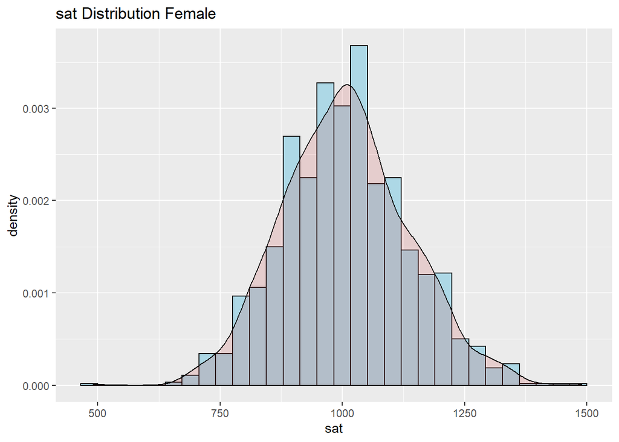

```r
##sat-female
df.female <- df %>% filter(female == TRUE)
df.male <- df %>% filter(female == FALSE)
#female
satfemale.ggplot <- ggplot( df.female, aes(x=sat)) +
  geom_histogram( aes(y=..density..), colour="black", fill="lightblue")+
  geom_density(alpha=.2, fill="indianred3") +
  labs(title = "sat Distribution Female")
satfemale.ggplot
```

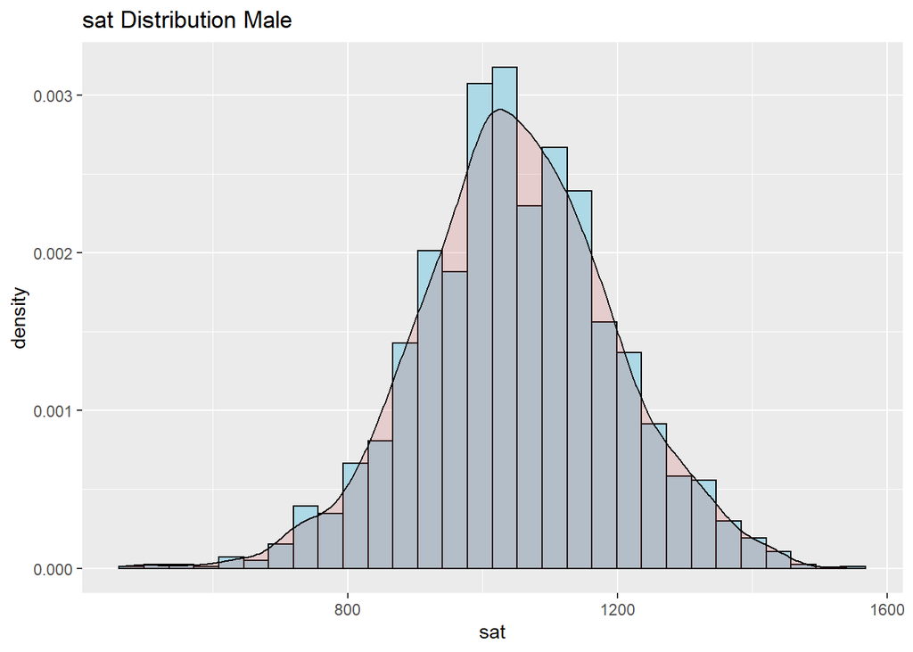

```r
#male
satmale.ggplot <- ggplot( df.male, aes(x=sat)) +
  geom_histogram( aes(y=..density..), colour="black", fill="lightblue")+
  geom_density(alpha=.2, fill="indianred3") +
  labs(title = "sat Distribution Male")
satmale.ggplot
```

```r
#ggplot grid
#grid.arrange(satfemale.ggplot, satmale.ggplot, ncol=2)
```

#### 2.2.2.2 Distribució *‘sat’* per *‘athlete’*

Visualització de la distribució de la variable *‘sat’* en funció de si és o no atleta.

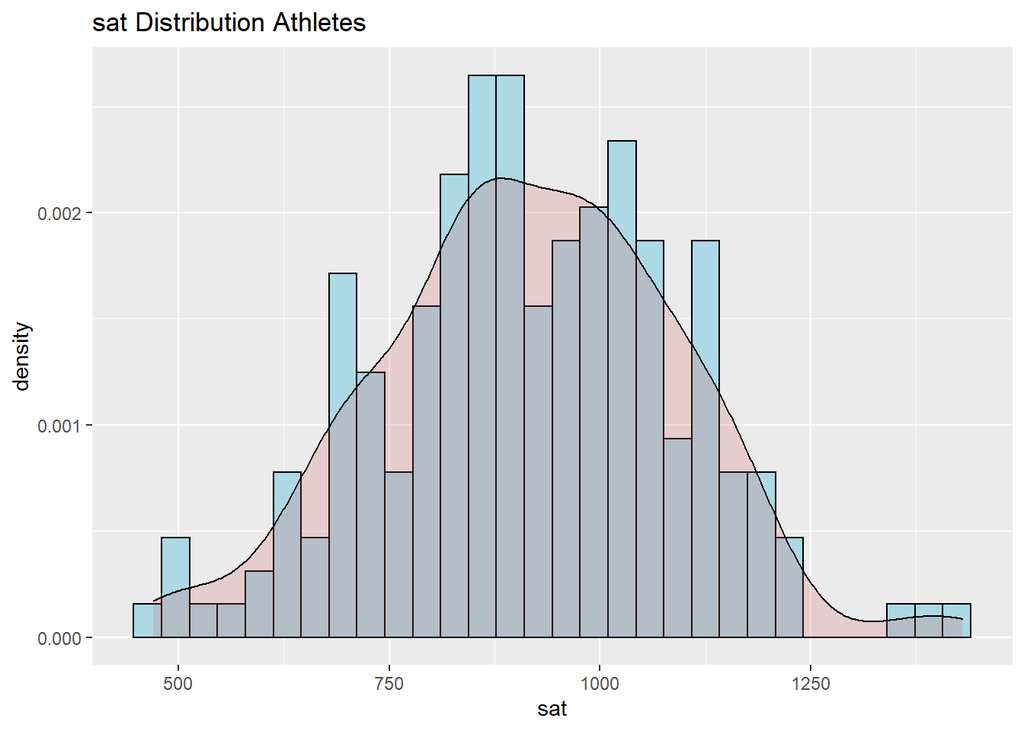

```r
##sat-athlete
df.athletes <- df %>% filter(athlete == TRUE)
df.noathletes <- df %>% filter(athlete == FALSE)

#athletes
satAthletes.ggplot <- ggplot( df.athletes, aes(x=sat)) +
  geom_histogram( aes(y=..density..), colour="black", fill="lightblue")+
  geom_density(alpha=.2, fill="indianred3") +
  labs(title = "sat Distribution Athletes")
satAthletes.ggplot
```

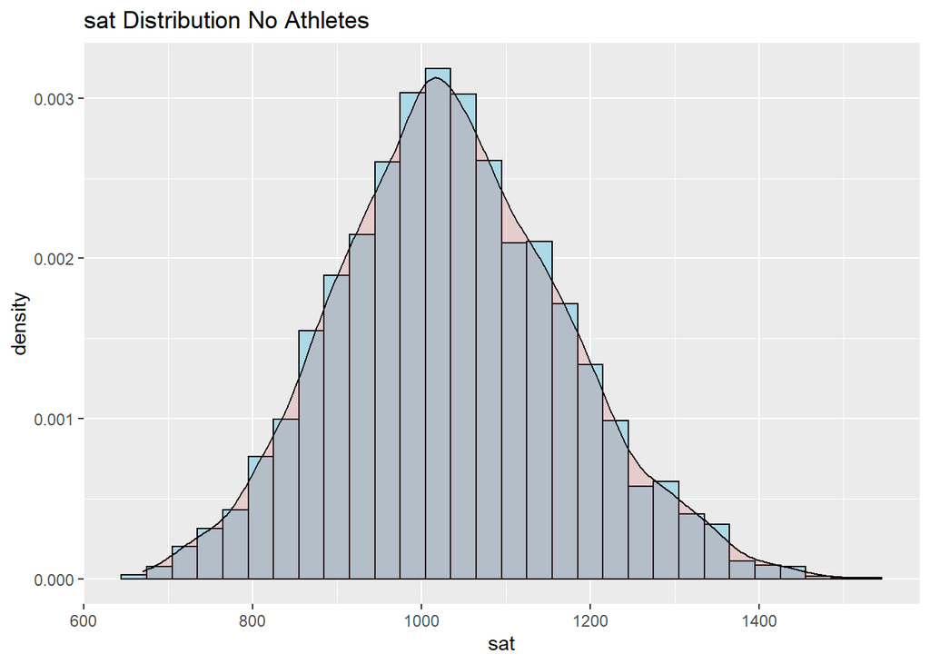

```r
#no athletes
satNoathletes.ggplot <- ggplot( df.noathletes, aes(x=sat)) +
  geom_histogram( aes(y=..density..), colour="black", fill="lightblue")+
  geom_density(alpha=.2, fill="indianred3") +
  labs(title = "sat Distribution No Athletes")
satNoathletes.ggplot
```

#### 2.2.2.3 Distribució *‘sat’* segons raça

Visualització de la distribució de la variable *‘sat’* en funció de la raça.

```r
##sat-race
df.white <- df %>% filter(white == TRUE)
df.black <- df %>% filter(black == FALSE)
df.noRace <- df %>% filter(black ==FALSE & white == FALSE)
count(df.noRace)
```

```
##    n
## 1 79
```

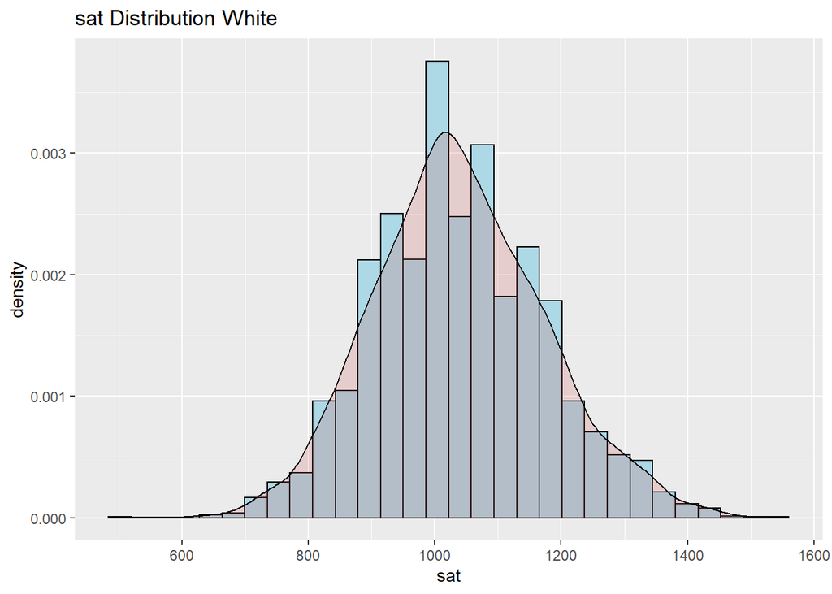

```r
#white
satWhite.ggplot <- ggplot( df.white, aes(x=sat)) +
  geom_histogram( aes(y=..density..), colour="black", fill="lightblue")+
  geom_density(alpha=.2, fill="indianred3") +
  labs(title = "sat Distribution White")
satWhite.ggplot
```

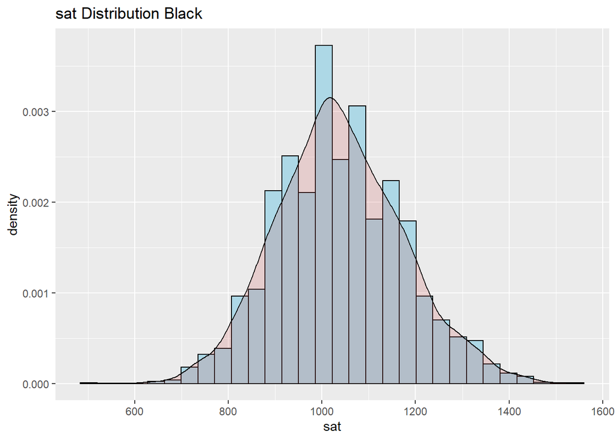

```r
#black
satBlack.ggplot <- ggplot( df.black, aes(x=sat)) +
  geom_histogram( aes(y=..density..), colour="black", fill="lightblue")+
  geom_density(alpha=.2, fill="indianred3") +
  labs(title = "sat Distribution Black")
satBlack.ggplot
```

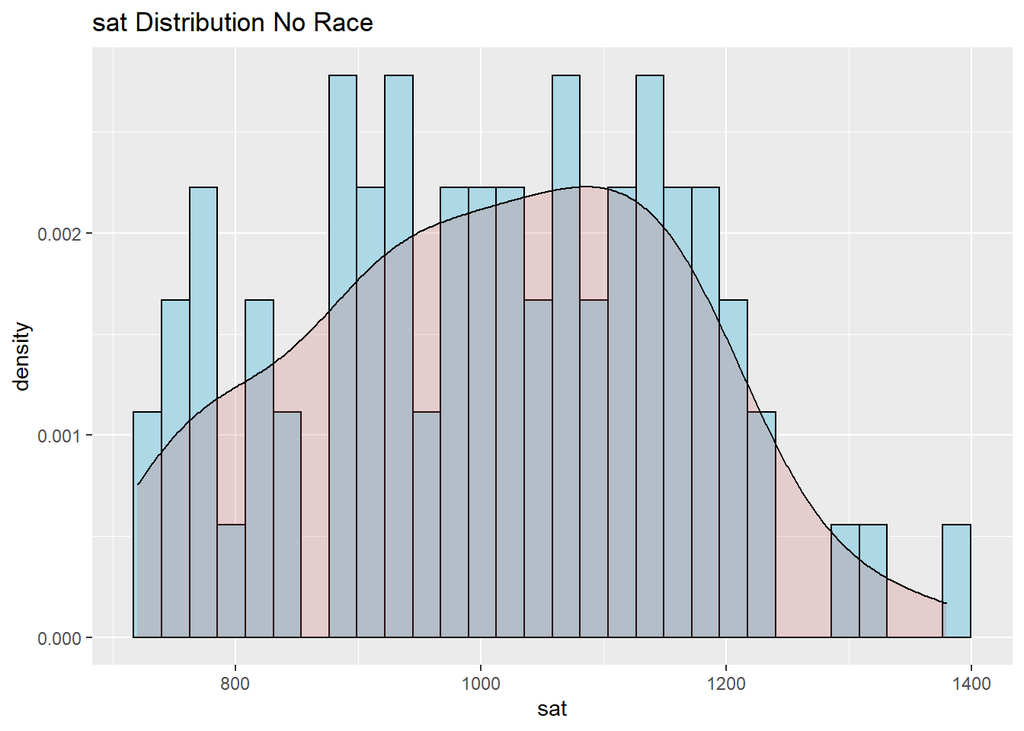

```r
#no race
satNorace.ggplot <- ggplot( df.noRace, aes(x=sat)) +
  geom_histogram( aes(y=..density..), colour="black", fill="lightblue")+
  geom_density(alpha=.2, fill="indianred3") +
  labs(title = "sat Distribution No Race")
satNorace.ggplot
```

### 2.2.3 Distribucions sobre *‘colgpa’*

#### 2.2.3.1 Distribució *‘colgpa’* per *‘female’*

Visualització de la distribució de la variable *‘colgpa’* en funció del gènere, variable *‘female’*.

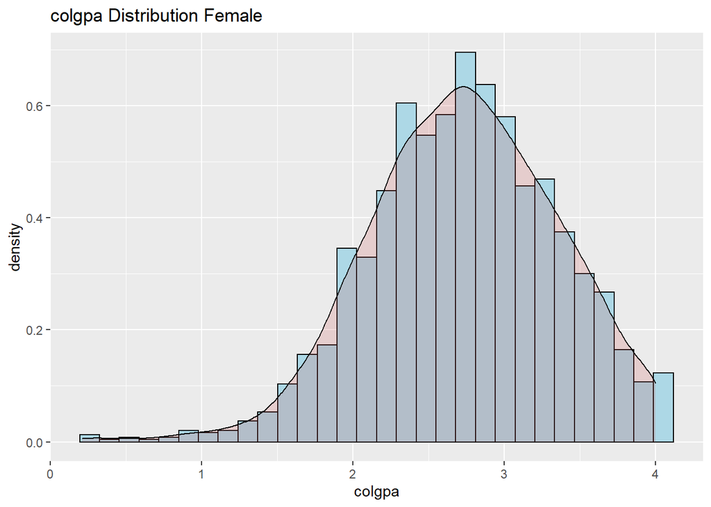

```r
##colgpa-female
#female
colgpafemale.ggplot <- ggplot( df.female, aes(x=colgpa)) +
  geom_histogram( aes(y=..density..), colour="black", fill="lightblue")+
  geom_density(alpha=.2, fill="indianred3") +
  labs(title = "colgpa Distribution Female")
colgpafemale.ggplot
```

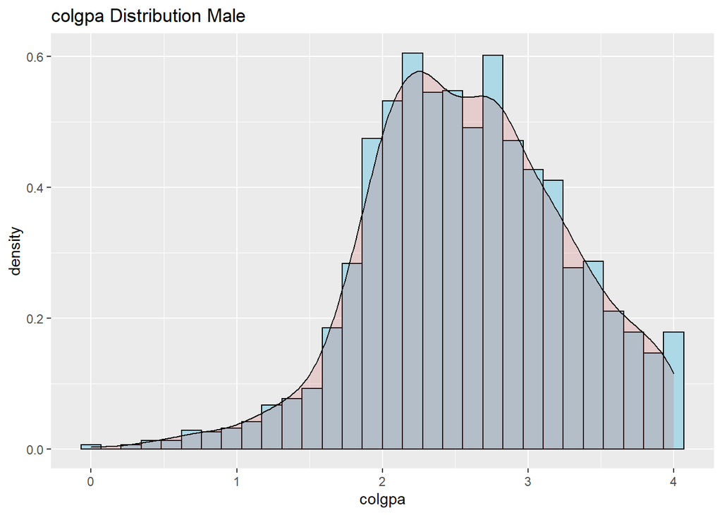

```r
#male
colgpamale.ggplot <- ggplot( df.male, aes(x=colgpa)) +
  geom_histogram( aes(y=..density..), colour="black", fill="lightblue")+
  geom_density(alpha=.2, fill="indianred3") +
  labs(title = "colgpa Distribution Male")
colgpamale.ggplot
```

```r
#ggplot grid
#grid.arrange(colgpafemale.ggplot, colgpamale.ggplot, ncol=2)
```

#### 2.2.3.2 Distribució *‘colgpa’* per *‘athlete’*

Visualització de la distribució de la variable *‘colgpa’* en funció de si és o no atleta.

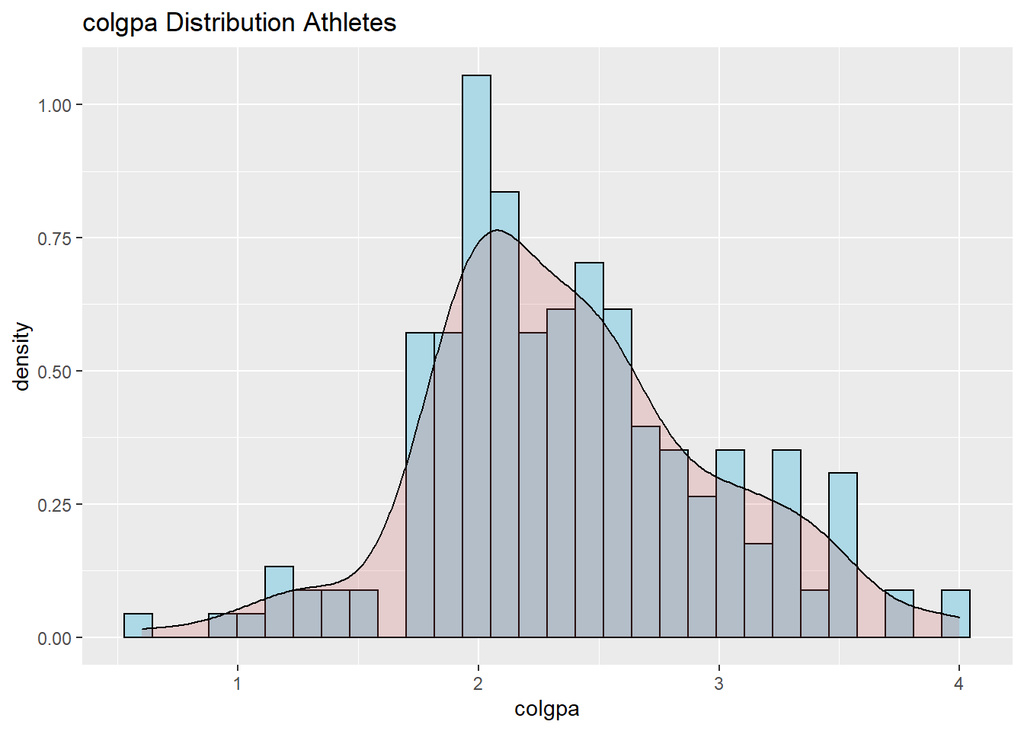

```r
##colgpa-athlete
#athletes
colgpaAthletes.ggplot <- ggplot( df.athletes, aes(x=colgpa)) +
  geom_histogram( aes(y=..density..), colour="black", fill="lightblue")+
  geom_density(alpha=.2, fill="indianred3") +
  labs(title = "colgpa Distribution Athletes")
colgpaAthletes.ggplot
```

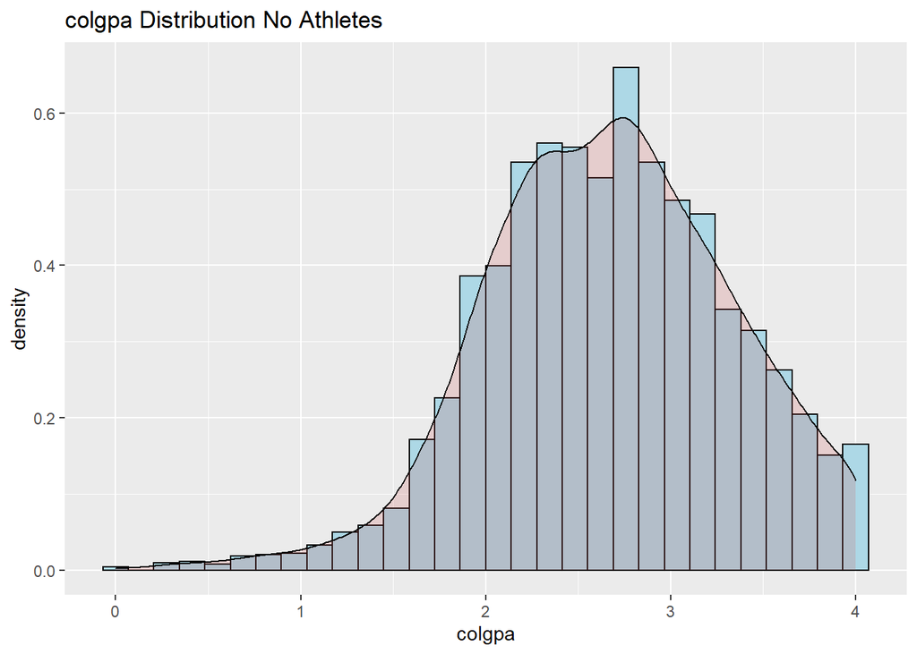

```r
#no athletes
colgpaNoathletes.ggplot <- ggplot( df.noathletes, aes(x=colgpa)) +
  geom_histogram( aes(y=..density..), colour="black", fill="lightblue")+
  geom_density(alpha=.2, fill="indianred3") +
  labs(title = "colgpa Distribution No Athletes")
colgpaNoathletes.ggplot
```

#### 2.2.3.3 Distribució *‘colgpa’* segons raça

Visualització de la distribució de la variable *‘colgpa’* en funció de la raça.

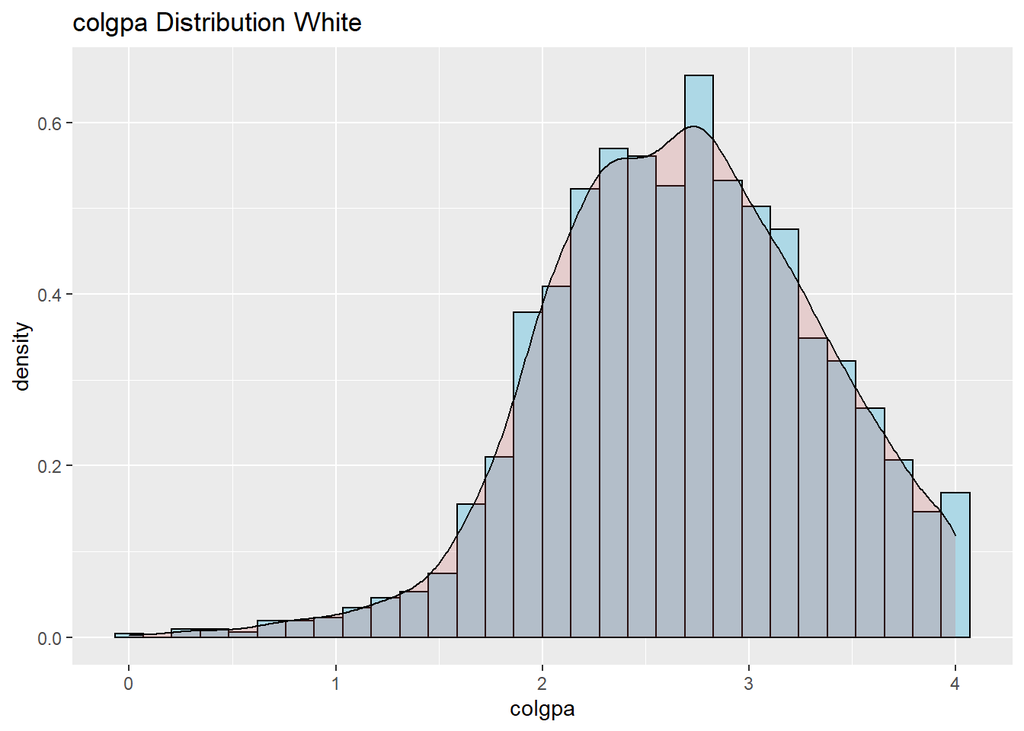

```r
##colgpa-race
#white
colgpaWhite.ggplot <- ggplot( df.white, aes(x=colgpa)) +
  geom_histogram( aes(y=..density..), colour="black", fill="lightblue")+
  geom_density(alpha=.2, fill="indianred3") +
  labs(title = "colgpa Distribution White")
colgpaWhite.ggplot
```

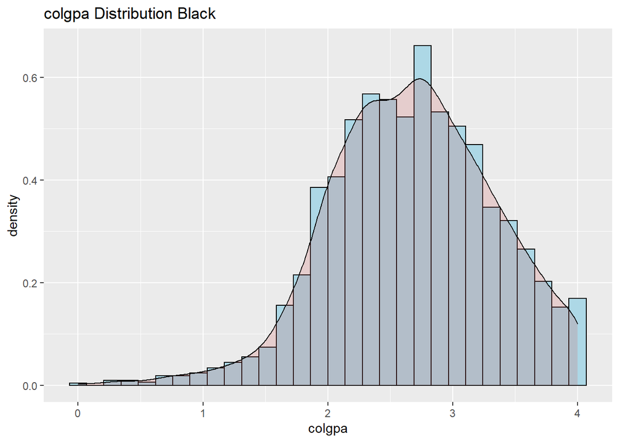

```r
#black
colgpaBlack.ggplot <- ggplot( df.black, aes(x=colgpa)) +
  geom_histogram( aes(y=..density..), colour="black", fill="lightblue")+
  geom_density(alpha=.2, fill="indianred3") +
  labs(title = "colgpa Distribution Black")
colgpaBlack.ggplot
```

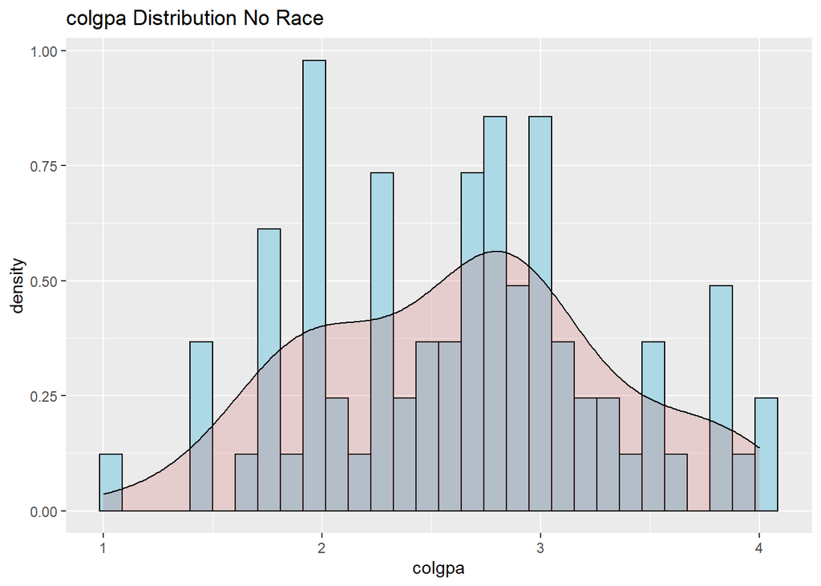

```r
#no race
colgpaNorace.ggplot <- ggplot( df.noRace, aes(x=colgpa)) +
  geom_histogram( aes(y=..density..), colour="black", fill="lightblue")+
  geom_density(alpha=.2, fill="indianred3") +
  labs(title = "colgpa Distribution No Race")
colgpaNorace.ggplot
```